# Networks: structure, evolution & processes

**Internet Analytics - Lab 2**

**Group:** *X*

**Names:**

- *Linqi LIU*
- *Yifei SONG*
- *Yuhang YAN*
- *Ying Xu Dempster TAY*

#### Instructions

*This is a template for part 1 of the lab. Clearly write your answers, comments and interpretations in Markodown cells. Don't forget that you can add $\LaTeX$ equations in these cells. Feel free to add or remove any cell.*

*Please properly comment your code. Code readability will be considered for grading. To avoid long cells of codes in the notebook, you can also embed long python functions and classes in a separate module. Don’t forget to hand in your module if that is the case. In multiple exercises, you are required to come up with your own method to solve various problems. Be creative and clearly motivate and explain your methods. Creativity and clarity will be considered for grading.*

## 2.1 Exploration of real networks

#### Exercise 2.1

1. Loads the graph:

```python
import networkx as nx

# Initialize an empty graph
G = nx.Graph()

# Load the graph from the CSV file
with open('../data/network1.csv', 'r') as file:
    for line in file:
        if not line.startswith('#'):
            i, j = line.strip().split(',')
            G.add_edge(i, j)
```

1. Numbers of nodes and edges:

```python
# Print out the number of nodes and edges
num_nodes = G.number_of_nodes()
num_edges = G.number_of_edges()
print(f"The graph contains {num_nodes} nodes and {num_edges} edges.")
```

```
The graph contains 13033 nodes and 18584 edges.
```

#### Exercise 2.2: Node degree distribution

1. To visualize the node degree distribution, a histogram is a useful type of plot.

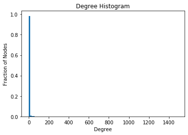

```python
import matplotlib.pyplot as plt

# Compute the degrees of each node
degree_sequence = [d for n, d in G.degree()]

# Calculate the total number of nodes
total_nodes = len(degree_sequence)

# Create a weight for each node such that the histogram reflects the proportion of nodes
weights = [1 / total_nodes for _ in degree_sequence]

# Create a histogram of the degree distribution, using weights to convert it into a proportion of nodes
plt.hist(degree_sequence, bins=100, weights=weights)
plt.title("Degree Histogram")
plt.xlabel("Degree")
plt.ylabel("Fraction of Nodes")
plt.show()
```

1. Properties of the degree distribution:

   (1) Large numbers are rare, smaller numbers are more common;

   (2) The degree distribution is skewed to the right;

   (3) The degree distribution is Heavy-tailed. While most nodes have a very low degree, there is a significant probability of finding nodes with very high degree.
1. The majority of nodes have a degree of less than 10, with only a very few nodes having a higher degree, and two nodes in particular has an extremely high degree of over a thousand. It is close to power law distribution. Code below showsthe estimation.

```python
import numpy as np

def estimate_power_law_alpha(degree_sequence):
    # Filter out degrees less than a chosen xmin.
    # This value is often chosen as the point where the power-law behavior seems to start
    xmin = min(degree_sequence)
    degrees = np.array([degree for degree in degree_sequence if degree >= xmin])

    n = len(degrees)  # number of observations
    # Calculate the summation term in the MLE formula
    summation = np.sum(np.log(degrees / xmin))

    # Estimate alpha using the MLE approximation
    alpha = 1 + n * (summation ** -1)

    return alpha, xmin

alpha, xmin = estimate_power_law_alpha(degree_sequence)

print(f"Estimated power-law alpha: {alpha}")
print(f"Chosen xmin: {xmin}")
```

```
Estimated power-law alpha: 3.432065585408249
Chosen xmin: 1
```

#### Exercise 2.3: Giant component

1. the number of connected components:

```python
# Find connected components
connected_components = list(nx.connected_components(G))
num_components = len(connected_components)
print(f"There are {num_components} connected components in the graph.")
```

```
There are 192 connected components in the graph.
```

1. There exists a giant component.

```python
# Find the largest connected component (giant component)
giant_component = max(connected_components, key=len)
size_giant_component = len(giant_component)
print(f"The giant component has {size_giant_component} nodes.")
```

```
The giant component has 12576 nodes.
```

#### Exercise 2.4: Short paths & Small-worlds

Given that network1 is very large, making computation extremely time-consuming, we use 1000 samples to estimate the path lengths between any two nodes in the network and the average number of nodes reachable within a distance r (in number of hops) from any other node in the network.

```python
import random

subgraph = G.subgraph(max(nx.connected_components(G), key=len))

# Define the number of nodes to sample
num_samples = 1000
nodes_sample = random.sample(subgraph.nodes(), num_samples)

# Collect all path lengths between sampled nodes
path_lengths = []
for node in nodes_sample:
    lengths = nx.single_source_shortest_path_length(subgraph, node)
    path_lengths.extend([length for target, length in lengths.items() if target != node])

# path_lengths now contains the shortest path lengths from each of the sampled nodes
# to all other nodes in the giant component, excluding self-paths.

# Compute the average shortest path length for the sample
avg_shortest_path_length_sample = np.mean(path_lengths)
print(f"Estimated average shortest path length in the giant component based on sample: \
{avg_shortest_path_length_sample}")
```

```
Estimated average shortest path length in the giant component based on sample: 4.153151332007952
```

the distribution of path lengths between any two nodes in the network：

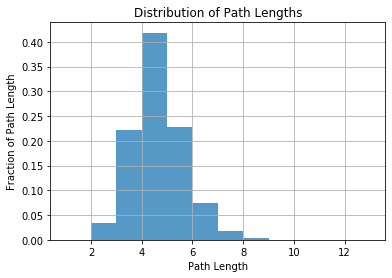

```python
# Calculate the total count of path lengths
total_path_lengths = len(path_lengths)

# Create a weight for each path length so the histogram displays the fraction of path lengths
weights = [1 / total_path_lengths for _ in path_lengths]

# Create a histogram of the path lengths distribution using weights
plt.hist(path_lengths, bins=range(1, max(path_lengths) + 2), weights=weights, alpha=0.75)
plt.title('Distribution of Path Lengths')
plt.xlabel('Path Length')
plt.ylabel('Fraction of Path Length')
plt.grid(True)
plt.show()
```

Calculate the average number of nodes reachable within a distance r (in number of hops) of any other node in the network：

```python
def average_reachable_nodes(G, max_r, num_samples=1000):
    reachable_nodes = []
    # Sample a subset of nodes if the graph is large
    nodes = list(G.nodes())
    sampled_nodes = random.sample(nodes, num_samples)

    for r in range(1, max_r + 1):
        reachable_count = []
        for node in sampled_nodes:
            reachable = nx.single_source_shortest_path_length(G, node, cutoff=r)
            reachable_count.append(len(reachable) - 1)  # subtract 1 to exclude the node itself
        avg_reachable = np.mean(reachable_count)
        reachable_nodes.append(avg_reachable)
    return reachable_nodes
```

```python
max_r = 6
# Calculate the average number of nodes reachable within a distance r using the sampled method
avg_reachable_per_hop = average_reachable_nodes(G, max_r)

# Output the results
for r, avg_reachable in enumerate(avg_reachable_per_hop, start=1):
    print(f"Average number of nodes reachable within {r} hops: {avg_reachable}")
```

```
Average number of nodes reachable within 1 hops: 2.195
Average number of nodes reachable within 2 hops: 389.198
Average number of nodes reachable within 3 hops: 2987.689
Average number of nodes reachable within 4 hops: 8029.009
Average number of nodes reachable within 5 hops: 10833.381
Average number of nodes reachable within 6 hops: 11800.526
```

Based on the information above, network1 is a typical small-world. Listed below are the reasons:

(1) The average shortest path length small, meaning most nodes are separated by only a few steps;

(2) There's a quick increase in the number of nodes reachable as the number of hops grows, showing effective network navigation, fitting the claim that every node is connected by an average of only “six degrees of separation”.

#### Exercise 2.5: Network comparison

#### 1.1.1 Loads the graph:

```python
import networkx as nx

# Initialize an empty graph
G2 = nx.Graph()

# Load the graph from the CSV file
with open('../data/network2.csv', 'r') as file:
    for line in file:
        if not line.startswith('#'):
            i, j = line.strip().split(',')
            G2.add_edge(i, j)
```

#### 1.1.2 Numbers of nodes and edges:

```python
# Print out the number of nodes and edges
num_nodes = G2.number_of_nodes()
num_edges = G2.number_of_edges()
print(f"The graph contains {num_nodes} nodes and {num_edges} edges.")
```

```
The graph contains 26542 nodes and 43516 edges.
```

#### 1.2.1 Visualize the node degree distribution using histogram:

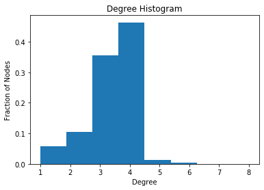

```python
import matplotlib.pyplot as plt

# Compute the degrees of each node
degree_sequence = [d for n, d in G2.degree()]

# Calculate the total number of nodes
total_nodes = len(degree_sequence)

# Create a weight for each node such that the histogram reflects the proportion of nodes
weights = [1 / total_nodes for _ in degree_sequence]

# Create a histogram of the degree distribution, using weights to convert it into a fraction of nodes
# Note: We use bins=8 as specified
plt.hist(degree_sequence, bins=8, weights=weights)
plt.title("Degree Histogram")
plt.xlabel("Degree")
plt.ylabel("Fraction of Nodes")
plt.show()
```

#### 1.2.2 Properties of the degree distribution:

(1) All the degrees of nodes are in range 1 to 8;

(2) The most common degree in the network is 4;

(3) There are very few nodes with a high degree (5, 6, 7, 8), suggesting the presence of a small number of hubs in the network.

#### 1.2.3

Seemingly, it is not very close to a well-known probability distribution. Still, we try to estimate it using poisson distribution and exponentiated exponential distribution. First, we'll estimate it by poisson distribution.

```python
import scipy.stats as stats

# Calculate the average degree (lambda for the Poisson distribution)
average_degree = (2 * num_edges) / num_nodes

# Generate the expected number of nodes for each degree from 1 to 6
print("Expected number of nodes for each degree:")
for k in range(1, 7):
    # Calculate the probability of k occurrences (degree k) using the Poisson PMF
    probability = stats.poisson.pmf(k, average_degree)
    # Estimate the expected number of nodes with degree k
    expected_nodes = probability * num_nodes
    print(f"Degree {k}: {expected_nodes:.2f}")

# Output the value of lambda (average_degree)
print(f"\nEstimated parameter λ (lambda) for the Poisson distribution: {average_degree:.2f}")
```

```
Expected number of nodes for each degree:
Degree 1: 3278.04
Degree 2: 5374.40
Degree 3: 5874.27
Degree 4: 4815.48
Degree 5: 3158.02
Degree 6: 1725.87

Estimated parameter λ (lambda) for the Poisson distribution: 3.28
```

We can see that it does not fit in very well. Next, we'll try to estimate it by exponentiated exponential distribution.

```python
from scipy.optimize import curve_fit
from scipy.special import gamma

# Define the probability density function for the exponentiated exponential distribution
def expexp_pdf(x, lamb, beta):
    return lamb * beta * np.exp(-lamb * x**beta) * x**(beta - 1)

# Create a histogram of degree distribution in a way that can be used for curve_fit
hist, bin_edges = np.histogram(degree_sequence, bins=8, weights=weights, density=True)
# Calculate the bin centers from bin_edges for fitting
bin_centers = (bin_edges[:-1] + bin_edges[1:]) / 2

# Provide an initial guess for the parameters
initial_guess = [1 / np.mean(degree_sequence), 1]

# Try to use curve_fit to fit the expexp_pdf function to the data with a higher maxfev

params, covariance = curve_fit(expexp_pdf, bin_centers, hist, p0=initial_guess, maxfev=5000)
lamb, beta = params
print(f"Estimated lambda: {lamb}")
print(f"Estimated beta: {beta}")
```

```
Estimated lambda: 0.00021542632006162183
Estimated beta: 6.257640423241612
```

We can see that the estimated lambda rather small, meaning that the degree distribution might not match the expected model. Thus, it is not very close to a well-known probability distribution.

#### 1.3.1 the number of connected components:

```python
# Find connected components
connected_components = list(nx.connected_components(G2))
num_components = len(connected_components)
print(f"There are {num_components} connected components in the graph.")
```

```
There are 5 connected components in the graph.
```

#### 1.3.2 There exists a giant component.

```python
# Find the largest connected component (giant component)
giant_component = max(connected_components, key=len)
size_giant_component = len(giant_component)
print(f"The giant component has {size_giant_component} nodes.")
```

```
The giant component has 26481 nodes.
```

#### 1.4.1

Similarly, given that network2 is very large, making computation extremely time-consuming, we use 1000 samples to estimate the path lengths between any two nodes in the network and the average number of nodes reachable within a distance r (in number of hops) from any other node in the network.

```python
subgraph = G2.subgraph(max(nx.connected_components(G2), key=len))

# Define the number of nodes to sample
num_samples = 1000
nodes_sample = random.sample(subgraph.nodes(), num_samples)

# Collect all path lengths between sampled nodes
path_lengths = []
for node in nodes_sample:
    lengths = nx.single_source_shortest_path_length(subgraph, node)
    path_lengths.extend([length for target, length in lengths.items() if target != node])

# path_lengths now contains the shortest path lengths from each of the sampled nodes
# to all other nodes in the giant component, excluding self-paths.

# Compute the average shortest path length for the sample
avg_shortest_path_length_sample = np.mean(path_lengths)
print(f"Estimated average shortest path length in the giant component based on sample: \
{avg_shortest_path_length_sample}")
```

```
Estimated average shortest path length in the giant component based on sample: 96.95537658610272
```

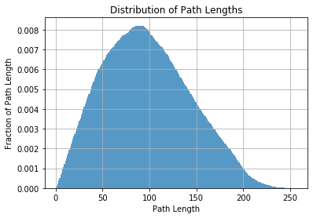

```python
# Calculate the total number of path lengths
total_path_lengths = len(path_lengths)

# Create a weight for each path length such that the histogram reflects the fraction of path lengths
weights = [1 / total_path_lengths for _ in path_lengths]

# Create a histogram of the path lengths distribution, using weights to convert it into a fraction of path lengths
plt.hist(path_lengths, bins=range(1, max(path_lengths) + 2), weights=weights, alpha=0.75)
plt.title('Distribution of Path Lengths')
plt.xlabel('Path Length')
plt.ylabel('Fraction of Path Length')
plt.grid(True)
plt.show()
```

```python
max_r = 6
# Calculate the average number of nodes reachable within a distance r using the sampled method
avg_reachable_per_hop = average_reachable_nodes(G2, max_r)

# Output the results
for r, avg_reachable in enumerate(avg_reachable_per_hop, start=1):
    print(f"Average number of nodes reachable within {r} hops: {avg_reachable}")
```

```
Average number of nodes reachable within 1 hops: 3.251
Average number of nodes reachable within 2 hops: 9.682
Average number of nodes reachable within 3 hops: 19.513
Average number of nodes reachable within 4 hops: 32.914
Average number of nodes reachable within 5 hops: 50.071
Average number of nodes reachable within 6 hops: 70.98
```

Based on the information above, network2 is probably not a typical small-world. Listed below are the reasons:

(1) The average shortest path length is relatively large, which is much longer than expected in a small-world network;

#### 2.1.1 The differences of the two networks:

Network1: (1)The number of connected components is larger; (2)Exhibits characteristics of a small-world network; (3)Has a short average path length, indicating that nodes are separated by only a few steps on average; (4)Shows a rapid increase in the number of nodes that can be reached as the number of hops grows, suggesting efficient network navigation;

In summary, Network1 is described as a small-world network with short path lengths and efficient navigation, whereas Network2 has longer path lengths and a slower increase in node reachability, pointing to a less efficient and possibly more regular network structure.

#### Exercise 2.6: Network identification

Network1 exhibits characteristics of a small-world network, such as a short average path length and rapid increase in node reachability, which is likely to be a subgraph of Internet routers. Internet router networks are designed to handle large volumes of data transmission, hence they are structured to allow information to be passed quickly between routers, which explains the short average path lengths.

Network2 has a very long average shortest path length and slower growth in node reachability, which is more consistent with the characteristics of a city road network. In urban road networks, due to geographical and planning constraints, paths are often not the most direct, and the number of roads (edges) connected at each intersection (node) is limited.

Therefore, based on the provided data and analysis, we can infer that Network1 is likely a subgraph of Internet routers, while Network2 is likely the road network around New York City.